# EPR Status Variation at the ADM-2 Level

Panel diagnostics and feasibility of cross-sectional analysis

Published

April 7, 2026

## Overview

This document assesses whether a **time-invariant (cross-sectional) variable** is a feasible and meaningful representation of ethnic group political status for ADM-2 subnational units, using the EPR panel (2000–2022).

### What is the panel?

The panel (`adm2_epr_panel.rds`) links two datasets:

- **EPR Core**: records which ethnic group holds which political status and when. The data are structured as *status episodes* — contiguous periods during which a group holds a given status without interruption (e.g., “the Tutsi were classified as Powerless from 1990 to 2003”). Each group can have multiple episodes if its status changed over time.
- **GeoEPR**: provides the geographic polygons of each group’s territorial base, also structured as episodes that can change if the group’s territorial control shifted.

These are intersected against GADM 4.10 ADM-2 boundaries. The result is a **balanced panel of 48,010 subnational units × 23 years (2000–2022)**, with ten variables measuring low-power and high-power ethnic group presence in each unit — unit-relative (area and population share) and country-relative (share of country area/population).

### What do the variables measure?

| Variable | Type | Definition |
| --- | --- | --- |
| `EPR_low_bin` | Binary | Any DISCRIMINATED or POWERLESS group overlaps this ADM-2 unit |
| `EPR_high_bin` | Binary | Any MONOPOLY, DOMINANT, or SENIOR PARTNER group overlaps |
| `EPR_low_pct` | Continuous [0,1] | Share of ADM-2 *area* covered by low-power group territory |
| `EPR_high_pct` | Continuous [0,1] | Share of ADM-2 *area* covered by high-power group territory |
| `EPR_low_pop_pct` | Continuous [0,1] | Share of ADM-2 *population* inside low-power territory |
| `EPR_high_pop_pct` | Continuous [0,1] | Share of ADM-2 *population* inside high-power territory |
| `EPR_low_country_area_pct` | Continuous [0,1] | Share of *country total area* contributed by this unit’s low-power territory |
| `EPR_high_country_area_pct` | Continuous [0,1] | Share of *country total area* contributed by this unit’s high-power territory |
| `EPR_low_country_pop_pct` | Continuous [0,1] | Share of *country total population* contributed by this unit’s low-power territory |
| `EPR_high_country_pop_pct` | Continuous [0,1] | Share of *country total population* contributed by this unit’s high-power territory |

**Low-power** groups are those the EPR codes as *Discriminated* or *Powerless*. **High-power** groups hold *Monopoly*, *Dominant*, or *Senior Partner* positions. A unit can simultaneously have both (different groups in different parts of the territory).

## Volatile and Transitioning Units

Top 30 ADM-2 units by within-unit SD of EPR_low_pct (most volatile)

| ADM-2 ID | ISO | Country | ADM-2 Name | SD (area) | Range (area) | SD (pop) | Ever low | Always low | Switches |
| --- | --- | --- | --- | --- | --- | --- | --- | --- | --- |
| CIV.2.2_1 | CIV | Côte d'Ivoire | Nawa | 0.511 | 1.000 | 0.511 | TRUE | FALSE | 1 |
| IRQ.1.1_1 | IRQ | Iraq | Abu Ghraib | 0.511 | 1.000 | 0.511 | TRUE | FALSE | 3 |
| CIV.2.1_1 | CIV | Côte d'Ivoire | Gbôkle | 0.510 | 0.999 | 0.510 | TRUE | FALSE | 1 |
| MMR.6.1_1 | MMR | Myanmar | Hpa-an | 0.510 | 0.998 | 0.509 | TRUE | FALSE | 1 |
| IRQ.13.3_1 | IRQ | Iraq | Ba`qubah | 0.509 | 1.000 | 0.508 | TRUE | FALSE | 3 |
| SSD.3.5_1 | SSD | South Sudan | Nahr Atiem | 0.507 | 0.996 | 0.508 | TRUE | TRUE | 0 |
| ETH.10.10_1 | ETH | Ethiopia | Gamo Gofa | 0.507 | 1.000 | 0.507 | TRUE | FALSE | 1 |
| ETH.10.11_1 | ETH | Ethiopia | Gedeo | 0.507 | 1.000 | 0.507 | TRUE | FALSE | 1 |
| ETH.10.13_1 | ETH | Ethiopia | Hadiya | 0.507 | 1.000 | 0.507 | TRUE | FALSE | 1 |
| ETH.10.16_1 | ETH | Ethiopia | Konso | 0.507 | 1.000 | 0.507 | TRUE | FALSE | 1 |
| ETH.10.18_1 | ETH | Ethiopia | Sheka | 0.507 | 1.000 | 0.507 | TRUE | FALSE | 1 |
| ETH.10.21_1 | ETH | Ethiopia | Wolayita | 0.507 | 1.000 | 0.507 | TRUE | FALSE | 1 |
| ETH.10.6_1 | ETH | Ethiopia | Burji | 0.507 | 1.000 | 0.507 | TRUE | FALSE | 1 |
| ETH.10.7_1 | ETH | Ethiopia | Dawro | 0.507 | 1.000 | 0.507 | TRUE | FALSE | 1 |
| IDN.12.5_1 | IDN | Indonesia | Kota Pontianak | 0.507 | 1.000 | 0.507 | TRUE | FALSE | 2 |
| IDN.16.2_1 | IDN | Indonesia | Bintan | 0.507 | 1.000 | 0.507 | TRUE | FALSE | 2 |
| IDN.16.7_1 | IDN | Indonesia | Tanjungpinang | 0.507 | 1.000 | 0.507 | TRUE | FALSE | 2 |
| IDN.31.11_1 | IDN | Indonesia | Ogan Komering Ulu Timur | 0.507 | 1.000 | 0.507 | TRUE | FALSE | 2 |
| IDN.31.14_1 | IDN | Indonesia | Palembang | 0.507 | 1.000 | 0.507 | TRUE | FALSE | 2 |
| IDN.31.6_1 | IDN | Indonesia | Musi Banyuasin | 0.507 | 1.000 | 0.507 | TRUE | FALSE | 2 |
| IDN.8.6_1 | IDN | Indonesia | Muaro Jambi | 0.507 | 1.000 | 0.507 | TRUE | FALSE | 2 |
| KEN.16.4_1 | KEN | Kenya | Bonchari | 0.507 | 1.000 | 0.507 | TRUE | FALSE | 4 |
| KEN.8.2_1 | KEN | Kenya | Kabondo Kasipul | 0.507 | 1.000 | 0.507 | TRUE | FALSE | 4 |
| MYS.8.1_1 | MYS | Malaysia | Bentong | 0.507 | 1.000 | 0.507 | TRUE | FALSE | 1 |
| MYS.8.3_1 | MYS | Malaysia | Cameron Highlands | 0.507 | 1.000 | 0.507 | TRUE | FALSE | 1 |
| MYS.8.9_1 | MYS | Malaysia | Raub | 0.507 | 1.000 | 0.507 | TRUE | FALSE | 1 |
| TGO.4.9_2 | TGO | Togo | Kpélé | 0.507 | 1.000 | 0.507 | TRUE | FALSE | 2 |
| USA.1.14_1 | USA | United States | Clay | 0.507 | 1.000 | 0.507 | TRUE | FALSE | 3 |
| USA.1.1_1 | USA | United States | Autauga | 0.507 | 1.000 | 0.507 | TRUE | FALSE | 3 |
| USA.1.26_1 | USA | United States | Elmore | 0.507 | 1.000 | 0.507 | TRUE | FALSE | 3 |

Note:  
'SD (area)' is the standard deviation of EPR_low_pct across 23 years for that unit. 'Switches' counts binary 0↔︎1 transitions. A unit can have high SD but zero switches (area share fluctuates while the binary flag stays 1).

Top 30 ADM-2 units with transient low-power exposure (ever low, but in fewer than half of years), sorted by number of binary switches

| ADM-2 ID | ISO | Country | ADM-2 Name | % yrs low | Switches | SD (area) | Range (area) |
| --- | --- | --- | --- | --- | --- | --- | --- |
| HUN.12.2_1 | HUN | Hungary | Esztergom | 43.5% | 5 | 0.008 | 0.016 |
| HUN.12.6_1 | HUN | Hungary | Tata | 43.5% | 5 | 0.001 | 0.001 |
| HUN.13.1_1 | HUN | Hungary | Balassagyarmat | 43.5% | 5 | 0.030 | 0.058 |
| HUN.13.5_1 | HUN | Hungary | Salgótarján | 43.5% | 5 | 0.026 | 0.052 |
| HUN.13.6_1 | HUN | Hungary | Szécsény | 43.5% | 5 | 0.001 | 0.002 |
| HUN.14.13_1 | HUN | Hungary | Szob | 43.5% | 5 | 0.020 | 0.039 |
| HUN.4.11_1 | HUN | Hungary | Sátoraljaújhely | 43.5% | 5 | 0.004 | 0.007 |
| HUN.4.1_1 | HUN | Hungary | Abaúj-Hegyközi | 43.5% | 5 | 0.006 | 0.011 |
| HUN.4.2_1 | HUN | Hungary | Bodrogközi | 43.5% | 5 | 0.004 | 0.008 |
| HUN.4.3_1 | HUN | Hungary | Edelényi | 43.5% | 5 | 0.012 | 0.023 |
| HUN.4.4_1 | HUN | Hungary | Encsi | 43.5% | 5 | 0.013 | 0.026 |
| HUN.4.5_1 | HUN | Hungary | Kazincbarcikai | 43.5% | 5 | 0.002 | 0.005 |
| HUN.4.9_1 | HUN | Hungary | Ózdi | 43.5% | 5 | 0.022 | 0.044 |
| SVK.1.10_1 | SVK | Slovakia | Velký Krtíš | 43.5% | 5 | 0.475 | 0.938 |
| SVK.1.13_1 | SVK | Slovakia | Zvolen | 43.5% | 5 | 0.053 | 0.105 |
| SVK.1.2_1 | SVK | Slovakia | Banská Štiavnica | 43.5% | 5 | 0.075 | 0.147 |
| SVK.1.5_1 | SVK | Slovakia | Krupina | 43.5% | 5 | 0.477 | 0.941 |
| SVK.1.6_1 | SVK | Slovakia | Lucenec | 43.5% | 5 | 0.199 | 0.393 |
| SVK.1.8_1 | SVK | Slovakia | Revúca | 43.5% | 5 | 0.091 | 0.179 |
| SVK.1.9_1 | SVK | Slovakia | Rimavská Sobota | 43.5% | 5 | 0.247 | 0.487 |
| SVK.2.8_1 | SVK | Slovakia | Senec | 43.5% | 5 | 0.032 | 0.062 |
| SVK.3.11_1 | SVK | Slovakia | Trebišov | 43.5% | 5 | 0.219 | 0.432 |
| SVK.3.1_1 | SVK | Slovakia | Gelnica | 43.5% | 5 | 0.025 | 0.050 |
| SVK.3.2_1 | SVK | Slovakia | Košice-okolie | 43.5% | 5 | 0.156 | 0.308 |
| SVK.3.8_1 | SVK | Slovakia | Rožnava | 43.5% | 5 | 0.211 | 0.417 |
| SVK.4.1_1 | SVK | Slovakia | Komárno | 43.5% | 5 | 0.490 | 0.966 |
| SVK.4.2_1 | SVK | Slovakia | Levice | 43.5% | 5 | 0.377 | 0.743 |
| SVK.4.3_1 | SVK | Slovakia | Nitra | 43.5% | 5 | 0.054 | 0.107 |
| SVK.4.4_1 | SVK | Slovakia | Nové Zámky | 43.5% | 5 | 0.505 | 0.997 |
| SVK.4.5_1 | SVK | Slovakia | Šala | 43.5% | 5 | 0.491 | 0.969 |

Note:  
These units are classified as 'exposed' under ever_low_bin but as 'unexposed' under majority_low_bin. They represent ambiguous cases where the choice of time-invariant construction matters.

## Part 2: Feasibility of a Time-Invariant Variable

If status is largely stable within units, a **time-invariant variable** — a single value per ADM-2 unit summarising its EPR exposure across the full period — becomes both feasible and meaningful for cross-sectional analysis.

We evaluate four candidate constructions for the binary and continuous cases.

### 2a. Binary candidates

Binary time-invariant candidates

| Candidate | n units | % units | Description |
| --- | --- | --- | --- |
| Ever low (any year) | 19820 | 41.3% | Widest net — includes transient exposure |
| Majority years low (≥50%) | 17300 | 36.0% | Conservative — chronic exposure only |
| Always low (all 23 years) | 9328 | 19.4% | Subset of majority: never non-low |
| Never low | 28190 | 58.7% | Baseline: no exposure in any year |

The gap between *ever low* and *majority years low* reveals how many units had **transient** exposure — low-status groups present for some years but not the majority. These units are the key point of disagreement between the two constructions.

Cross-tab: ever_low_bin × majority_low_bin. Units that disagree: 2520 / 48010 (5.2%)

| ever_low_bin | Majority non-low (0) | Majority low (1) |
| --- | --- | --- |
| Never low (0) | 28190 | 0 |
| Ever low (1) | 2520 | 17300 |

Note:  
Off-diagonal cells are units classified differently by the two constructions. These are units with low-status group present in some years but fewer than half.

### 2b. Continuous candidates

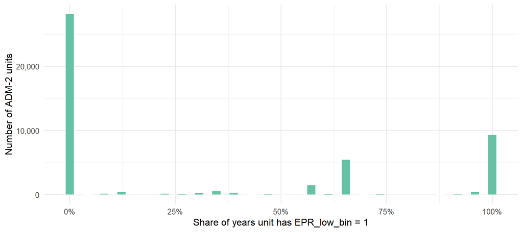

Distribution of the share of years each ADM-2 unit spends in low-power status (pct_yrs_low). The two spikes at 0 and 1 correspond to permanently unexposed and permanently exposed units respectively.

Summary statistics for continuous time-invariant candidates

| Candidate | Mean | Median | SD | % zero |
| --- | --- | --- | --- | --- |
| Mean area share (mean_low_pct) | 0.2190 | 0 | 0.3383 | 58.7% |
| Initial value / year 2000 (initial_low_pct) | 0.2739 | 0 | 0.4242 | 62.5% |
| Median area share (modal_low_pct) | 0.2605 | 0 | 0.4176 | 64.0% |

Note:  
A high % zero reflects units with no low-power group overlap in any year (or only in the reference year for the initial value). Between-unit SD is the key figure for cross-section identification: higher SD = more variation to exploit.

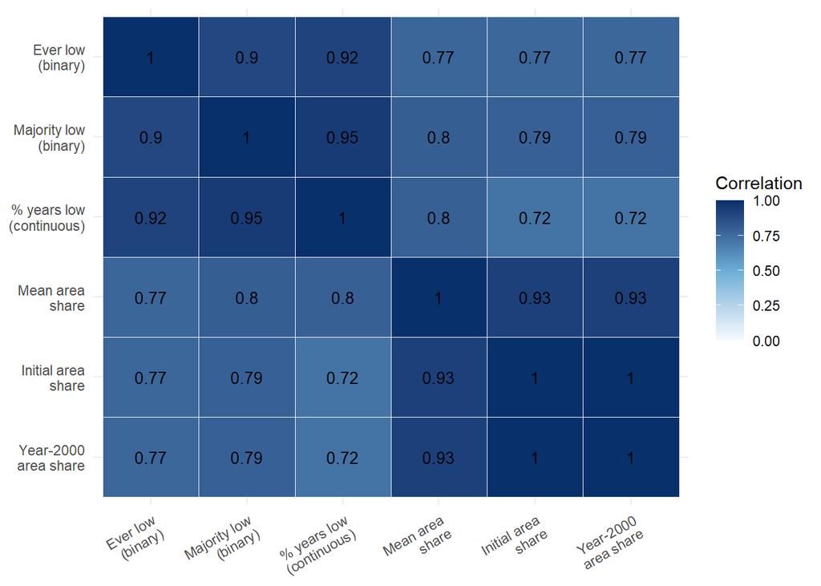

Correlation matrix of time-invariant candidate variables. High correlations indicate the choice of construction makes little difference to unit rankings.

**How to read the correlation matrix:** Each cell shows the Pearson correlation between two candidate variables computed across all 48,010 ADM-2 units. A value of 1.00 on the diagonal is trivial (a variable is perfectly correlated with itself). The off-diagonal values are what matter.

A **high correlation** (e.g., 0.90+) between two candidates means that units rank similarly on both measures — knowing one tells you almost everything about the other. In that case, the choice between them is largely cosmetic: results in a regression will be nearly identical regardless of which you use.

A **low correlation** would mean the two candidates assign very different exposure values to some units — choosing one vs. the other would change which units are classified as “exposed” and could meaningfully alter regression results.

**What to look for here:**

- *Ever-exposed vs. majority-exposed*: the correlation between `ever_low_bin` and `majority_low_bin` tells you how often the two disagree. The off-diagonal disagreements are units low-status in some years but fewer than half — the transient-exposure cases identified in the Volatile and Transitioning Units section above.
- *Binary vs. continuous*: these correlations are naturally lower because a binary variable loses information about *how much* of the unit is covered. Even so, a high correlation means that units with large area shares tend to be the ones flagged as low-power.
- *Long-run mean vs. baseline snapshot*: correlations among `mean_low_pct`, `initial_low_pct`, and `low_pct_2000` tell you whether the 23-year average is well-approximated by a single-year snapshot. If yes, using the year-2000 value as a predetermined variable is defensible without much loss of information.

## Summary

Key diagnostics at a glance

| Finding | Value |
| --- | --- |
| Share of ADM-2 units with stable EPR_low_bin | 78.1% |
| Share of ADM-2 units with stable EPR_high_bin | 94.8% |
| Median within-unit SD of EPR_low_pct | 0.0000 |
| Units permanently unexposed (EPR_low_bin always 0) | 28,190 |
| Units permanently exposed (EPR_low_bin always 1) | 9,328 |
| Units with transient exposure (ever but not majority low) | 2,520 |
| Correlation: ever_low_bin vs mean_low_pct | 0.772 |

**Take-aways for the co-author:**

1. **Most units are time-stable in the binary sense.** The large majority never cross the low-power/high-power boundary. This limits the scope for panel identification via within-unit variation, but makes cross-sectional analysis well-motivated.
2. **The continuous variable moves more than the binary, but not by much.** Median within-unit SD is close to zero. Variation in the continuous measure comes largely from the tail of volatile units.
3. **A time-invariant variable is feasible.** Candidates agree closely with one another (high correlations). The *ever-low* binary and the *mean area share* are natural choices: the former for clean interpretation, the latter for a richer continuous exposure measure.
4. **Transient exposure is the main ambiguity.** Units that were low-status for some years but not the majority are classified differently by *ever-low* vs *majority-low*. The share of such units and whether they differ systematically from chronic-exposure units is worth examining in the substantive analysis.

*Generated 2026-04-07 21:26*